# Your Digest for Saturday, Jan 13, 2024 11:59 PM

13/01/2024

[output not shown]

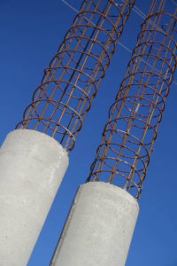

+ **Bone pain** + **tenderness**, Muscle *weakness*,

- **Imaging**: Reduced bone mineral density. Severe form -> "cod fish" concave vertebrae. **Looser zones** - insufficiency fractures seen as radiolucent areas in bone seen mostly in **femoral neck, femoral shaft** and pubic and ischial rami.
- **Labs**: ⬇ Ca2+, ⬇ PO43-, ⬇Vitamin D, **⬆** *Alkaline phosphatase*.
  - In **CKD bone disease**, there will be **phosphate retention**

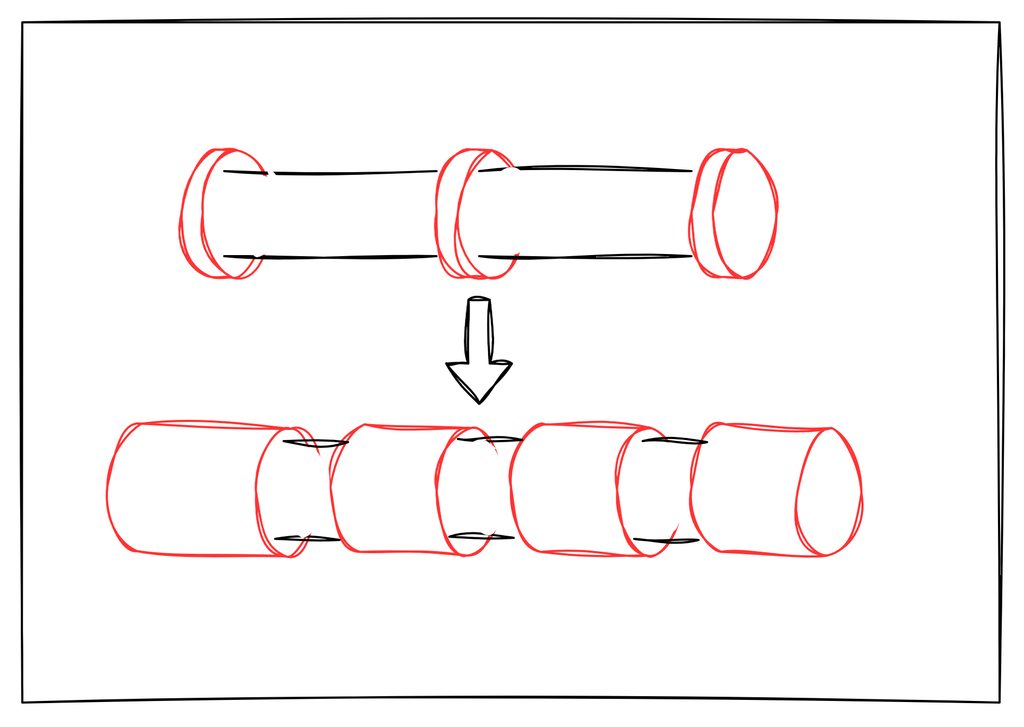

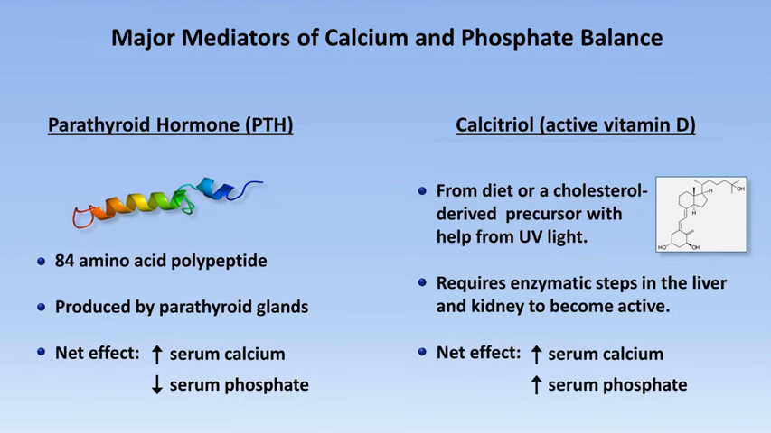

[figure not shown]

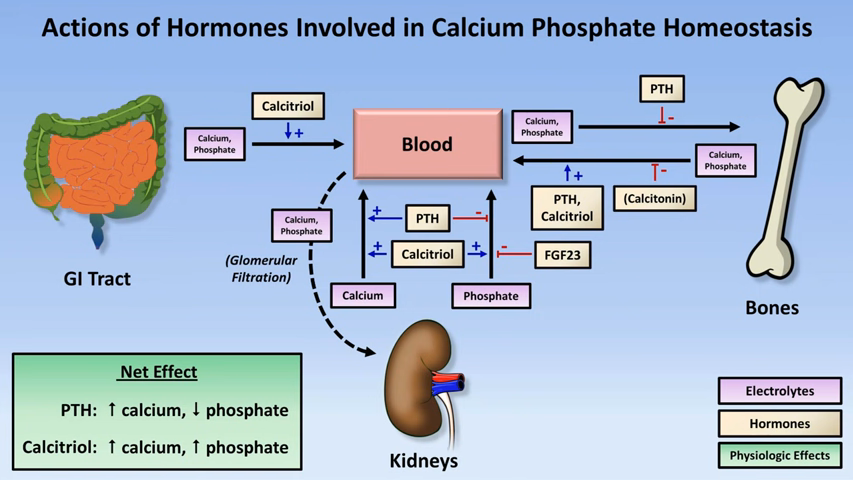

# Q 7: Erythema nodosum

> [!TIP] Painful Panniculitis with Plethora of causes.

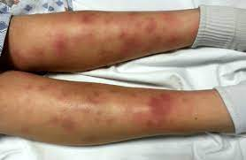

> [!TIP] Mnemonic:  
> **NODOSUM**  
> N : No causes in 80% of cases  
> O : Obstetric -> Pregnancy  
> D : Drugs (sulfonamides; amoxicillin)  
> O : Oral contraceptive pills  
> S : Sarcoidosis/ Tuberculosis  
> U : Ulcerative colitis; Crohn's disease; Behcet disease  
> M: Micro
> - Viral : HSV; EBV; Hep B; Hep C
> - Bacterial: campylobacter; salmonella; streptococci; Brucellosis
> - Parasite : Amoebiasis; Giardiasis

> [!INFO] Stimuli for parathyroid hormone secretion  
> Important triggers for PTH secretion are
> 1. **hypocalcemia** and
> 2. **hyperphosphatemia** [Source](https://www.ncbi.nlm.nih.gov/books/NBK557822/)  
>    [!INFO] Net effect: ⬆Ca and ⬇Phosphate  
>    Main action is to '**mobilize calcium from bone**' and **increase renal phosphate excretion**.
- ⬆ osteoclastic activity in bone (*a rapid response*)
- ⬆ intestinal absorption of calcium *VIA production of calcitriol* (which *takes about 1 day* to respond)
- ⬆ 1α-hydroxylation of vitamin D (the rate-limiting step)
- ⬆ renal tubular reabsorption of calcium.
- It has a **phosphaturic** action (by **inhibiting NaPi-IIa** active transporter which is found in the **PCT**)
  - Mnemonic: *P*TH *P*CT
- Parathyroid hormone secretion is directly *inhibited by high calcium levels.*
- This happens through **binding of calcium to a GPCR** on the parathyroid cells called **CaR**.

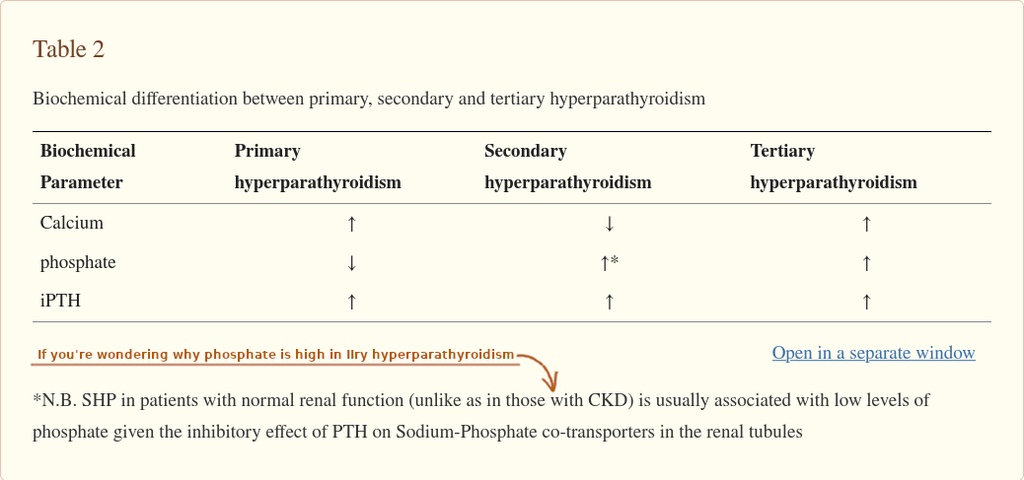

> [!INFO] **Serum PTH** can be interpreted correctly only when **serum calcium is measured simultaneously**
- **Hypocalcemia** with *low or inapproprirately normal PTH level*
- **Commonest cause is post surgical**. (roughly 80%)
- If not that, it is *autoimmune*. (roughly 20%)
- Caused by a **defect in PTH receptor** caused by mutation of a protein coupled to the receptor (GNAS-1)
- Results in **end organ resistance to PTH**
- Biochemical manifestations are just like hypoparathyroidism (Low Ca2+ and high Phosphate)
- **BUT** having **HIGH PTH level**
  - associated with low IQ, short stature, shortened 4th and 5th metacarpals

> Albright's hereditary osteodystrophy (AHO) is a characteristic skeletal phenotype, including **short stature**, **obesity**, **round face**, and **brachydactyly**. AHO appears in patients with *pseudohypoparathyroidism* (PHP) who have resistance to PTH and in their eumetabolic family members who have *pseudopseudohypoparathyroidism* (PPHP).

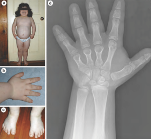

Bind to bone hydroxyapetite and **inhibit osteoclasts**.

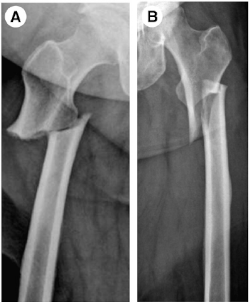

> [!TIP] B3 mnemonic  
> B3 -> CC (cassal Collar ) and DDDD
- Notes: release of **niacin** from certain legumes like corn is possible only when the corn is prepared in alkaline medium (tortias). So pellagra can be prevalent even in areas which have abundance of legumes. (i.e India)
- Infantile beri beri occurs when mom is B1 deficient and breast milk has low B1 => Cardiomegaly, tachycardia, dyspnoea, vomiting etc.
- Adult beri beri ⌹ into wet and dry
- **Triad** of **OPHTHALMOPLEGIA, ataxia, confusion**, + **nystagmus** + *lower limb* *polyneuropathy*.

> **Dry beriberi**:  
> is the development of a *symmetrical peripheral neuropathy characterized by both **sensory** and **motor** impairments*, mostly of the distal extremities.(**peripheral neuropathy**, muscle **weakness**, **brisk tendon reflexes**, seizures).  
> "Dry beriberi is characterized by **severe burning dysesthesias** (feet more than hands), **weakness and wasting** (distal more than proximal), trophic changes (shiny skin, hair loss), and acrodistal sensory loss in a graded fashion typical of **dying-back polyneuropathies**."  
> **Wet beriberi**  
> includes signs of **cardiac involvement** with *cardiomegaly*, *cardiomyopathy*, **High output heart failure**, peripheral edema, and tachycardia, **in addition to neuropathy**

# Pyoderma gangrenosum

**Pyoderma gangrenosum** (PG) is a rare **neutrophilic dermatosis** that presents with rapidly developing, painful skin ulcers hallmarked by undermined borders and peripheral erythema. Epidemiological studies indicate that the average age of PG onset is in the mid-40s. [Source](https://www.nature.com/articles/s41572-020-0213-x)

- Acute onset
- Purpule
- Undermined edge
- Painful
- Multiple ulcers

**Biopsy**: *neutrophilic* infiltrate.

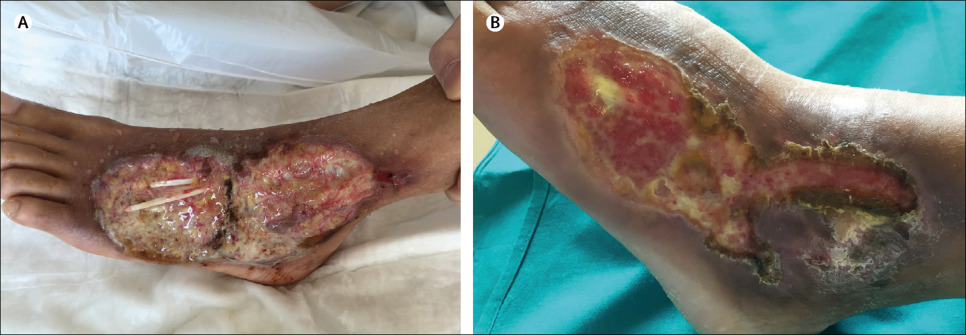